# TMA4215 - Project 1 - Emil Myhre

## Problem 1:

The induced matrix norm $\lVert \cdot \rVert_{2}$ is given as $\lVert A \rVert_{2} = \sqrt{p(A^{T}A)}$, where p is the spectral radius of a given matrix, meaning the maximum absolute value of its eigenvalues.

In order to proove $\lVert uv^{T} \rVert_{2} = \lVert u \rVert_{2} \cdot \lVert v \rVert_{2}$

we use the definition of the induced matrix

$\lVert uv^{T} \rVert_{2} = \sqrt{p((uv^{T})^{T}uv^{T})} = \sqrt{p(vu^{T}uv^{T})}$

From the definition

$\lVert A \rVert_{2} = \sqrt{p(A^{T}A)}$

we can write

$\sqrt{\lVert u \rVert_{2}^{2}p(vv^{T})} = \lVert u \rVert_{2} \cdot \sqrt{p(vv^{T})}$

By solving the equation

$vv^{T}x = x\lambda$

Substituting x for v:

$vv^{T}v = v\lambda$

$v^{T}v = \lambda$

Now we can substitute $p(vv^{T})$ with $\lVert v \rVert_{2}$

Thus

$\lVert uv^{T} \rVert_{2} = \lVert u \rVert_{2} \cdot \lVert v \rVert_{2}$

## Problem 2:

From the definition of condition numbers, we have:

$k_{2}(A) = \lVert A \rVert_{2} \cdot \lVert A^{-1} \rVert_{2}$

Given a symmetrical matrix, we have $A^{T} = A$, which leads to:

$\lVert A \rVert_{2} = \sqrt{p(A^{T}A)} = \sqrt{p(A^{2})} = \sqrt{(p(A))^{2}} = p(A)$

where $p(A)$ is defined as $\mid \lambda_{max} \mid$

Similarly, we have for $\lVert A^{-1} \rVert_{2}$:

$\lVert A^{-1} \rVert_{2} = \sqrt{p((A^{-1})^{T}A^{-1})} = \sqrt{p(A^{-1})^{2})} = \sqrt{(p(A^{-1}))^{2}} = p(A^{-1})$

The eigenvalues of $A^{-1}$ will naturally be $\frac{1}{\lambda}$, thus the spectral radius, $p(A^{-1})$, is given as $\mid \frac{1}{\lambda_{min}} \mid$

Finally, this leads to $k_{2}(A) = \lVert A \rVert_{2} \cdot \lVert A^{-1} \rVert_{2} = \mid\lambda_{max}\mid \cdot \mid\frac{1}{\lambda_{min}}\mid = \mid\frac{\lambda_{max}}{\lambda_{min}}\mid$

$k_{2}(A) = \mid\frac{\lambda_{max}}{\lambda_{min}}\mid$

## Problem 3:

Given the matrix $n x n$ matrix A, such that $a_{ij} = 1$ for j $\geq$ i and $a_{ij} = 0$ for $j < i$, we can find $A^{-1}$ by performing row reduction to the following matrix

\begin{equation*} \begin{vmatrix} 1 & 1 & 1 & 1 & 1 & 0 & 0 & 0\\ 0 & 1 & 1 & 1 & 0 & 1 & 0 & 0 \\ 0 & 0 & 1 & 1 & 0 & 0 & 1 & 0 \\ 0 & 0 & 0 & 1 & 0 & 0 & 0 & 1 \end{vmatrix} \end{equation*}

consisting of $A$ and $I$. By reducing the left side to $I$, the right side of the matrix will convert to $A^{-1}$, because $A \cdot A^{-1} = I$.

\begin{equation*} \begin{vmatrix} 1 & 0 & 0 & 0 & \mathbf{1} & \mathbf{-1} & \mathbf{0} & \mathbf{0}\\ 0 & 1 & 0 & 0 & \mathbf{0} & \mathbf{1} & \mathbf{-1} & \mathbf{0} \\ 0 & 0 & 1 & 0 & \mathbf{0} & \mathbf{0} & \mathbf{1} & \mathbf{-1} \\ 0 & 0 & 0 & 1 & \mathbf{0} & \mathbf{0} & \mathbf{0} & \mathbf{1} \end{vmatrix} \end{equation*}

As we see, $A^{-1}$ can be expressed as an $n x n$ matrix with $a_{ij} = -1$ for $j = i + 1$, $a_{ij} = 1$ for $j = i$, and else, $a_{ij} = 0$.

To determine $\mid\frac{\lambda_{max}}{\lambda_{min}}\mid$, I have implemented a simple python code to calculate the eigenvalues of the matrix.

```python
import numpy as np
import matplotlib.pyplot as plt
import math

n = 13
matrix = np.zeros([n,n])
for i in range(n):
    for j in range(n):
        if (i == j):
            matrix[i][j] = 1
        if (j == i + 1):
            matrix[i][j] = 1
        if (j > i):
            matrix[i][j] = 1
print(np.linalg.eigvals(matrix))
```

```
[ 1.  1.  1.  1.  1.  1.  1.  1.  1.  1.  1.  1.  1.]
```

Clearly, all the eigenvalues are equal to 1. Thus, $\mid\frac{\lambda_{max}}{\lambda_{min}}\mid = 1$ as well.

To determine the condition numbers $k_{1}(A)$ and $k_{\infty}(A)$, we use the definitions of condition numbers.

$k_{1}(A) = \lVert A \rVert_{1} \cdot \lVert A^{-1} \rVert_{1}$

Where $\lVert A \rVert_{1}$ is defined as $\max\limits_{1 \leq j \leq n}\sum_{i=1}^{n} \mid a_{ij} \mid$

From this definition we can easily calculate

$\lVert A \rVert_{1} = n$ and $\lVert A^{-1} \rVert_{1} = 2$

Which yields $k_{1}(A) = 2n$

Similarily, we have

$k_{\infty}(A) = \lVert A \rVert_{\infty} \cdot \lVert A^{-1} \rVert_{\infty}$

where $\lVert A \rVert_{\infty}$ is defined as $\max\limits_{1 \leq i \leq n}\sum_{j=1}^{n} \mid a_{ij} \mid$

Equally, we have $\lVert A \rVert_{\infty} = n$ and $\lVert A^{-1} \rVert_{\infty} = 2$

Which gives Which yields $k_{\infty}(A) = 2n$

In the following python code, the condition number $k_{2}$ is investigated numerically.

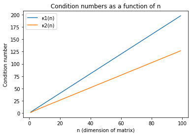

```python
import numpy as np
import matplotlib.pyplot as plt
import math

k1 = []
k2 = []
list = []

for n in range(1,100):
    list.append(n)
    k1.append(2*n)
    matrix = np.zeros([n,n])
    inverseMatrix = np.zeros([n,n])
    for i in range(n):
        for j in range(n):
            if (i == j):
                matrix[i][j] = 1
                inverseMatrix[i][j] = 1
            if (j == i + 1):
                inverseMatrix[i][j] = -1
                matrix[i][j] = 1
            if (j > i):
                matrix[i][j] = 1
    matrixProduct = np.dot(matrix,np.transpose(matrix))
    inverseMatrixProduct = np.dot(inverseMatrix,np.transpose(inverseMatrix))
    eigenvalues1 = np.linalg.eigvals(matrixProduct)
    eigenvalues2 = np.linalg.eigvals(inverseMatrixProduct)
    for eigenvalue in eigenvalues1:
        eigenvalue = abs(eigenvalue)
    for eigenvalue in eigenvalues2:
        eigenvalue = abs(eigenvalue)
    specrad1 = np.sqrt(max(eigenvalues1))
    specrad2 = np.sqrt(max(eigenvalues2))
    k_2 = specrad1 * specrad2
    k2.append(k_2)

plt.plot(list,k1,label='κ1(n)')
plt.plot(list,k2,label='κ2(n)')
plt.title("Condition numbers as a function of n")
plt.xlabel('n (dimension of matrix)')
plt.ylabel('Condition number')
plt.legend()
plt.show()
```

By studiyng the graph, we observe that $k_{2}(A)$ is approximately linear, at least not constant equal to 1. Thus we can conclude that the relation $k_{2}(A) = \mid\frac{\lambda_{max}}{\lambda_{min}}\mid$ does not hold for non-symmetric matrices.

# Problem 4:

In this problem I am going to analyze the bound $\frac{\lVert \delta x \rVert}{\lVert x \rVert} \leq \frac{k(A)}{1 - k(A)\cdot \frac{\lVert \delta A \rVert}{\lVert A \rVert}} (\frac{\lVert \delta b \rVert}{\lVert b \rVert} + \frac{\lVert \delta A \rVert}{\lVert A \rVert})$

By simplifying the problem, we set $\lVert \delta A \rVert = 0$, which yields the bound

$\frac{\frac{\lVert \delta x \rVert}{\lVert x \rVert}}{\frac{\lVert \delta b \rVert}{\lVert b \rVert}} \leq k(A)$

In the following code I am calculating "kappa*est", $\frac{\frac{\lVert \delta x \rVert}{\lVert x \rVert}}{\frac{\lVert \delta b \rVert}{\lVert b \rVert}}$, numerically, and comparing this to "K2", $k*{2}(A)$.

```
K2:  17.0821442999
Kappa_est: 1.41717198644
```

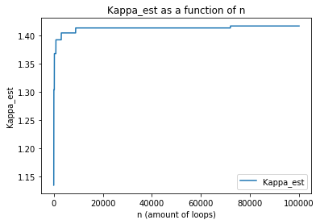

```python
import numpy as np
import matplotlib.pyplot as plt
import math

n = 13
matrix = np.zeros([n,n])  #matrisen A
inverseMatrix = np.zeros([n,n])
for i in range(n):
    for j in range(n):
        if (i == j):
            matrix[i][j] = 1
            inverseMatrix[i][j] = 1
        if (j == i + 1):
            inverseMatrix[i][j] = -1
            matrix[i][j] = 1
        if (j > i):
            matrix[i][j] = 1
b = []
for i in range(n):
    b.append(1- 2*np.random.random_sample())
b = np.asarray(b)

x = np.linalg.solve(matrix,b) #finner løsingen på likningen Ax = b
matrix_norm = np.linalg.norm(matrix,2) #normen til matrisen A
invMatrix_norm = np.linalg.norm(inverseMatrix,2) #normen til inversA
b_norm = np.linalg.norm(b,2) #normen til vektoren B
x_norm = np.linalg.norm(x,2)
k2 = matrix_norm * invMatrix_norm #condition number k2(A)

steps = []
kappa_est_list = []
kappa_est = 0
NEXPS = 100000
for k in range(0,NEXPS):
    delta_b = []
    for i in range(n):
        delta_b.append((1- 2*np.random.random_sample())/10)
    delta_b = np.asarray(delta_b)
    delta_x = np.linalg.solve(matrix,delta_b)
    delta_x_norm = np.linalg.norm(delta_x)
    delta_b_norm = np.linalg.norm(delta_b)
    kappa_c = (delta_x_norm / x_norm) / (delta_b_norm / b_norm)
    kappa_est = max(kappa_est,kappa_c)
    kappa_est_list.append(kappa_est)
    steps.append(k)
print("K2: ",k2)
print("Kappa_est:", kappa_est)
plt.plot(steps,kappa_est_list,label="Kappa_est")
plt.title("Kappa_est as a function of n")
plt.xlabel('n (amount of loops)')
plt.ylabel('Kappa_est')
plt.legend()
plt.show()
```

We observe that the bound is satisfied, because of the randomly generated numbers, the result does vary. However, usually I get to approximately 10% of the bound.